# SmartPhos: SmartPhos Protocol

# 5 Perform Differential expression analysis

Perform differential expression analyis using limma package. Reference condition is “unstimulated” and the target condition is “HGF”.

```r
deaT <- performDifferentialExp(se = se50, assay = "imputed",
                               method = "limma", condition = "treatment",
                               reference = "unstimulated", target = "HGF")

datatable(deaT$resDE, options = list(pageLength = 5), caption = "Results") %>%
  formatSignif(columns = c("log2FC", "stat", "pvalue", "padj"), digits = 4)
```

|  | ID | log2FC | stat | pvalue | padj | UniprotID | Gene | Position | Residue | Sequence | site |
| --- | --- | --- | --- | --- | --- | --- | --- | --- | --- | --- | --- |
| 1 | s9051 | 3.695344131099313 | 45.98748825626861 | 6.077816910542038e-10 | 4.759773941518477e-06 | Q06124 | PTPN11 | 580 | Y | REDSARVYENVGLMQ | PTPN11_Y580 |
| 2 | s6746 | -8.413289111921515 | -43.59099830108966 | 8.827473927148511e-10 | 4.759773941518477e-06 | P46821 | MAP1B | 1819 | S | ATCHSSSSPPIDAAS | MAP1B_S1819 |
| 3 | s3981 | 2.492620689248967 | 23.85870069870817 | 5.825506962979937e-08 | 0.0002094075569625854 | P08581 | MET | 1003 | Y | VSNESVDYRATFPED | MET_Y1003 |
| 4 | s24116 | -1.490505270624493 | -20.07278423034156 | 1.920908770318685e-07 | 0.0004189024654786906 | Q9H4G0 | EPB41L1 | 639 | S | AFEDFSRSLPELDRD | EPB41L1_S639 |
| 5 | s3466 | 4.84112088998687 | 20.04063102637232 | 1.942240659674938e-07 | 0.0004189024654786906 | O96017 | CHEK2 | 379 | S | SKILGETSLMRTLCG | CHEK2_S379 |
| 6 | s16018 | 1.18595233382361 | 17.62066558839424 | 4.704304286149548e-07 | 0.0008455202903639454 | Q7Z4S6 | KIF21A | 853 | S | GKVTRKLSSSDAPAQ | KIF21A_S853 |
| 7 | s14005 | 1.209890561724158 | 16.75118786223824 | 6.653705072994083e-07 | 0.000988522908961697 | Q63ZY3 | KANK2 | 540 | S | EPRERVPSVAEAPQL | KANK2_S540 |
| 8 | s10444 | 2.003868814941565 | 16.51478290215613 | 7.333256001199534e-07 | 0.000988522908961697 | Q13480 | GAB1 | 659 | Y | VADERVDYVVVDQQK | GAB1_Y659 |
| 9 | s7861 | -1.286897507615937 | -15.54234082627623 | 1.109983243862953e-06 | 0.001330006589090899 | P55196 | AFDN | 1501 | S | DLQYITVSKEELSSG | AFDN_S1501 |
| 10 | s7527 | 2.25127126940145 | 14.39516613472559 | 1.870563237221192e-06 | 0.002017215395019334 | P51812 | RPS6KA3 | 375 | S | DSPGIPPSANAHQLF | RPS6KA3_S375 |

[output cut: 10774 more lines]

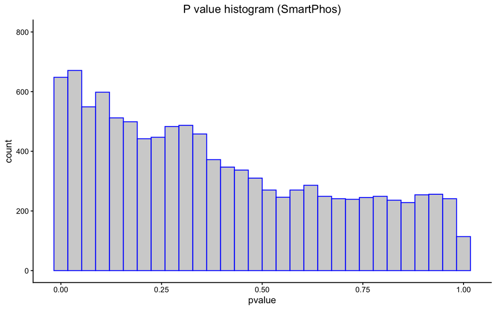

```r
p <- ggplot(deaT$resDE, aes(x = pvalue)) +
  geom_histogram(fill = "grey", col = "blue", alpha=0.7) +
  ggtitle("P value histogram (SmartPhos)") + theme_classic() +
  theme(plot.title = element_text(hjust = 0.5)) + ylim(0, 800)

p
```

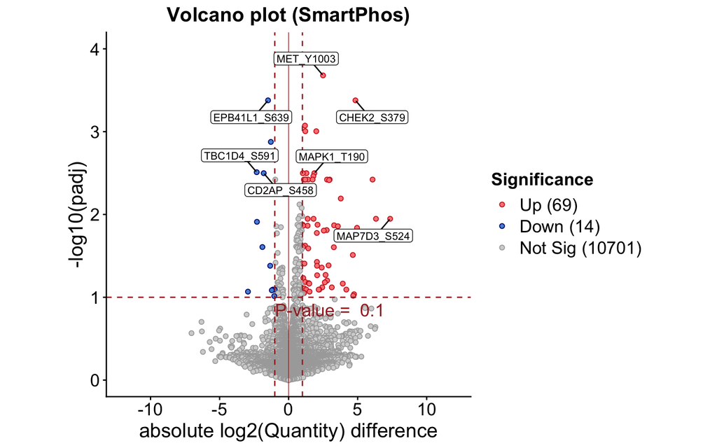

```r
labels <- c("MET_Y1003", "MAPK1_T190", "MAP7D3_S524", "CHEK2_S379", "CD2AP_S458",
            "TBC1D4_S591", "EPB41L1_S639")
topLabels <- deaT$resDE[deaT$resDE$site %in% labels,]
plotVolcanoDEA(deaT$resDE, fcFilter = 1, pFilter = 0.1, usePadj = TRUE) +
  ylim(0, 4) + xlim(-12, 12) +
  geom_label_repel(
    data = topLabels,
    aes(label = site,
        colour = ifelse(log2FC > 0, "red", "blue")),
    size = 3,
    max.overlaps = 10,
    fill = "white",             # background color of box
    color = "black",            # text color
    label.size = 0.25,          # border thickness
    label.padding = unit(0.15, "lines"), # space around text
    label.r = unit(0.15, "lines"),       # corner radius
    box.padding = 0.5
  ) +
  ggtitle("Volcano plot (SmartPhos)")
```

# 6 Enrichment analysis

We use Cancer Hallmark geneset to perform enrichment analysis. We can use other genesets also, provided the geneset file is in .gmt format.

```r
# Load the gene set
genesetPath <- system.file("shiny-app/geneset", package = "SmartPhos")
inGMT <- piano::loadGSC(paste0(genesetPath,"/Cancer_Hallmark.gmt"), type="gmt")
# Call the function
resTab <- enrichDifferential(dea = deaT$resDE, type = "Pathway enrichment",
                             gsaMethod = "PAGE", geneSet = inGMT,
                             statType = "stat", nPerm = 200, sigLevel = 0.05,
                             ifFDR = FALSE)
```

```
## Checking arguments...done!
```

```
## Adjusting for multiple testing...done!
```

```r
datatable(resTab, options = list(pageLength = 5)) %>%
  formatRound(columns = c("Stat", "p.up", "p.up.adj", "p.down", "p.down.adj"),
               digits = 3)
```

|  | Name | Gene Number | Stat | p.up | p.up.adj | p.down | p.down.adj | Number up | Number down |
| --- | --- | --- | --- | --- | --- | --- | --- | --- | --- |
| 1 | HALLMARK_PI3K_AKT_MTOR_SIGNALING | 43 | 4.9632 | 3.4669e-07 | 1.6988e-05 | 1 | 1 | 27 | 16 |
| 2 | HALLMARK_IL6_JAK_STAT3_SIGNALING | 15 | 3.8896 | 5.0209e-05 | 0.0012301 | 0.99995 | 1 | 9 | 6 |
| 3 | HALLMARK_PROTEIN_SECRETION | 34 | 2.0572 | 0.019832 | 0.32392 | 0.98017 | 1 | 21 | 13 |
| 4 | HALLMARK_HYPOXIA | 43 | 1.9306 | 0.026769 | 0.32792 | 0.97323 | 1 | 31 | 12 |
| 5 | HALLMARK_MYOGENESIS | 30 | -1.7374 | 0.95884 | 0.95884 | 0.041162 | 0.83899 | 13 | 17 |

# 7 Kinase Activity Inference

Kinase activity inference is based on phosphopeptides that are differentially expressed. The activity is estimated by an activity score computed with the package decoupleR: [Badia-I-Mompel et al., 2022](https://doi.org/10.1093/bioadv/vbac016)

```r
netw <- getDecouplerNetwork("Homo sapiens")
scoreTabT <- calcKinaseScore(deaT$resDE, netw, statType = "stat", nPerm = 500)
```

The kinase activity is computed from comparing two conditions, hence it is important to take into account the conditions when interpreting the result. A positive score means that the kinase is more active in the selected condition compared to the reference one, while a negative score means that the kinase is more active in the reference condition.

```r
datatable(scoreTabT, options = list(pageLength = 10)) %>%
  formatRound(columns = c("score", "p_value"), digits = 3)
```

|  | source | score | p_value |
| --- | --- | --- | --- |
| 1 | ABL1 | 0.6903755696390688 | 0.516 |
| 2 | AKT1 | 1.796236834548991 | 0.004 |
| 3 | AKT2 | 2.581841336009599 | 0.004 |
| 4 | AKT3 | 3.379872461521397 | 0.024 |
| 5 | ATM | 0.1491405804558559 | 0.4159999999999999 |
| 6 | ATR | -0.1039885920040514 | 0.288 |
| 7 | AURKA | 1.668591378730372 | 0.036 |
| 8 | AURKB | 0.2460993862060546 | 0.688 |
| 9 | BUB1 | 0.5297002672036901 | 0.796 |
| 10 | CAMK2A | -0.4805816870824212 | 0.876 |

[output cut: 117 more lines]

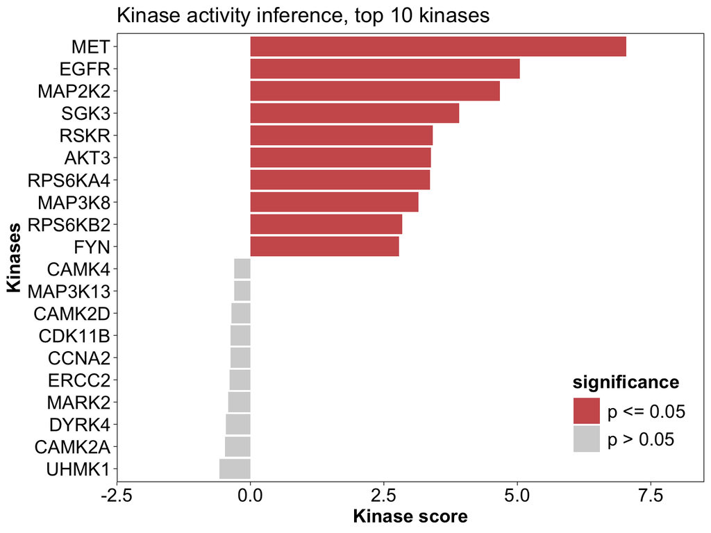

```r
p <- plotKinaseDE(scoreTabT, nTop = 10, pCut = 0.05) + ylim(-2, 8) +
  theme(
    legend.position = c(0.98, 0.05),
    legend.justification = c(1, 0),
    panel.grid = element_blank()
  )
p
```

# 8 Compare DEA results

```r
maeInSol <- mae[, mae$experiment == "InSolution"]
seInSol <- maeInSol[["Phosphoproteome"]]
colData(seInSol) <- colData(maeInSol)
newSEInSol <- preprocessPhos(seData = seInSol, transform = "log2", normalize = TRUE,
                        impute = "QRILC")
```

```
## Imputing along margin 2 (samples/columns).
```

```r
dea <- performDifferentialExp(se = newSEInSol, assay = "imputed", method = "limma",
                              condition = "treatment", reference = "unstimulated",
                              target = "HGF")

common_sites <- intersect(deaT$resDE$site, dea$resDE$site)

resDE1 <- deaT$resDE
resDE2 <- dea$resDE


compare_df <- inner_join(
  resDE1 %>% select(site, log2FC, pvalue),
  resDE2 %>% select(site, log2FC, pvalue),
  by = "site",
  suffix = c("_tc", "_isd")
)
```

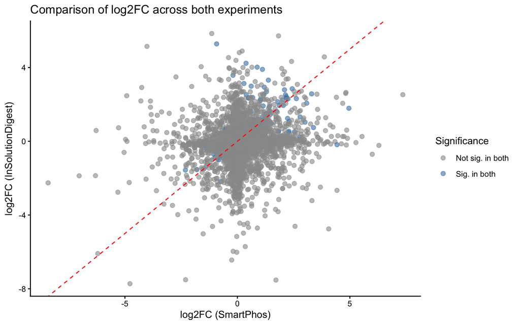

```r
compare_df_unique <- compare_df %>%
  distinct(site, .keep_all = TRUE)

ggplot(compare_df_unique, aes(x = log2FC_tc, y = log2FC_isd)) +
  geom_point(aes(color = (pvalue_tc < 0.05 & pvalue_isd < 0.05)), alpha = 0.6, size = 2) +
  geom_abline(intercept = 0, slope = 1, color = "red", linetype = "dashed") +
  scale_color_manual(values = c("grey60", "steelblue"),
                     labels = c("Not sig. in both", "Sig. in both"),
                     name = "Significance") +
  labs(
    title = "Comparison of log2FC across both experiments",
    x = "log2FC (SmartPhos)",
    y = "log2FC (InSolutionDigest)"
  ) +
  theme_classic()
```

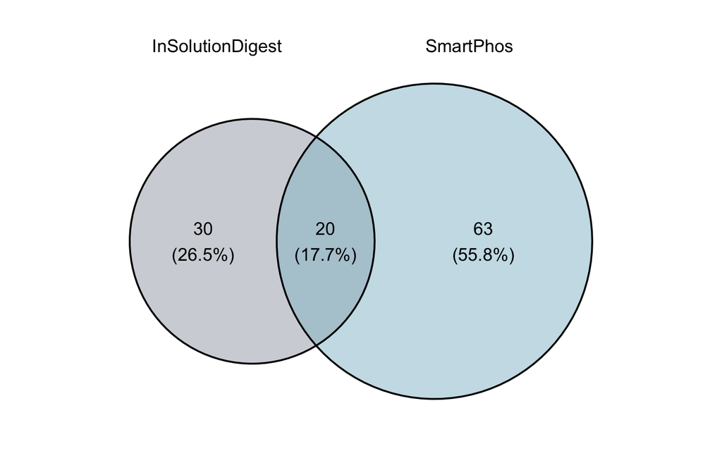

```r
library(ggvenn)

sig1 <- resDE1[resDE1$padj < 0.1 & abs(resDE1$log2FC) >= 1, ]$site
sig2 <- resDE2[resDE2$padj < 0.1 & abs(resDE2$log2FC) >= 1, ]$site

venn_list <- list(InSolutionDigest = sig2, SmartPhos = sig1)

ggvenn(venn_list,
       fill_color = c("#a3a7b2", "#90bfce"),
       stroke_size = 0.7, set_name_size = 5, text_size = 5, auto_scale = TRUE)
```